# 589 project

## **homogeneous PCF** plot

**Strong clustering at small distances**:

- The observed PCF rises sharply to values **above 30** at short distances.
- This indicates **very strong local clustering**, far exceeding what the model based on `Dist_Water` explains.

Suggests that assuming homogeneity (i.e., ignoring spatial covariates like `Dist_Water`) is not realistic for this data.

## **inhomogeneous PCF** plot

**`Dist_Water` alone cannot explain fine-scale clustering** of the squirrels.

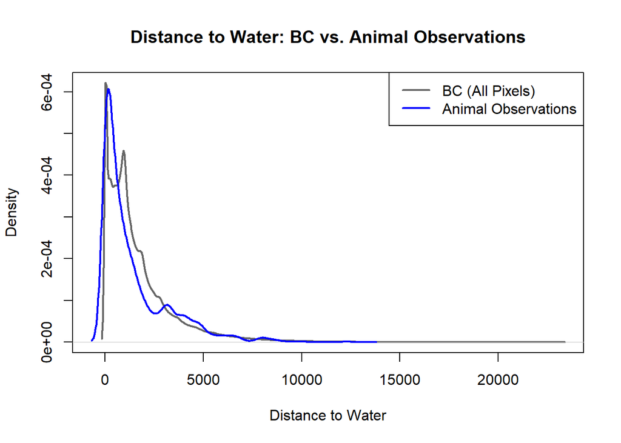

```r
# Extract all pixel values of Dist_Water across BC
dist_all <- DATA$Dist_Water$v
dist_all <- dist_all[!is.na(dist_all)]

# Extract Dist_Water values at animal observation locations
dist_at_animals <- interp.im(DATA$Dist_Water, DATA$Animal$X, DATA$Animal$Y)
dist_at_animals <- dist_at_animals[!is.na(dist_at_animals)]

# Compute KDEs
kde_dist_all <- density(dist_all)
kde_dist_animals <- density(dist_at_animals)

# Plot both KDEs
plot(kde_dist_all,
     main = "Distance to Water: BC vs. Animal Observations",
     xlab = "Distance to Water",
     ylab = "Density",
     col = "gray40", lwd = 2,
     xlim = range(c(kde_dist_all$x, kde_dist_animals$x)))
lines(kde_dist_animals, col = "blue", lwd = 2)


# Add legend
legend("topright",
       legend = c("BC (All Pixels)", "Animal Observations"),
       col = c("gray40", "blue"),
       lwd = 2)
```

## KDE plot

This supports our earlier finding from `rhohat()`, the inhomogeneous K-function, and our intensity map.